# Exercise 7

Baily

2023-10-24

```r
frogs <- read.csv("frogs.csv")
```

```r
options(width = 90)
```

Response: pres.abs Predictor varibles: Altitude, distance, NoOfPools, NoOfSites, avrain

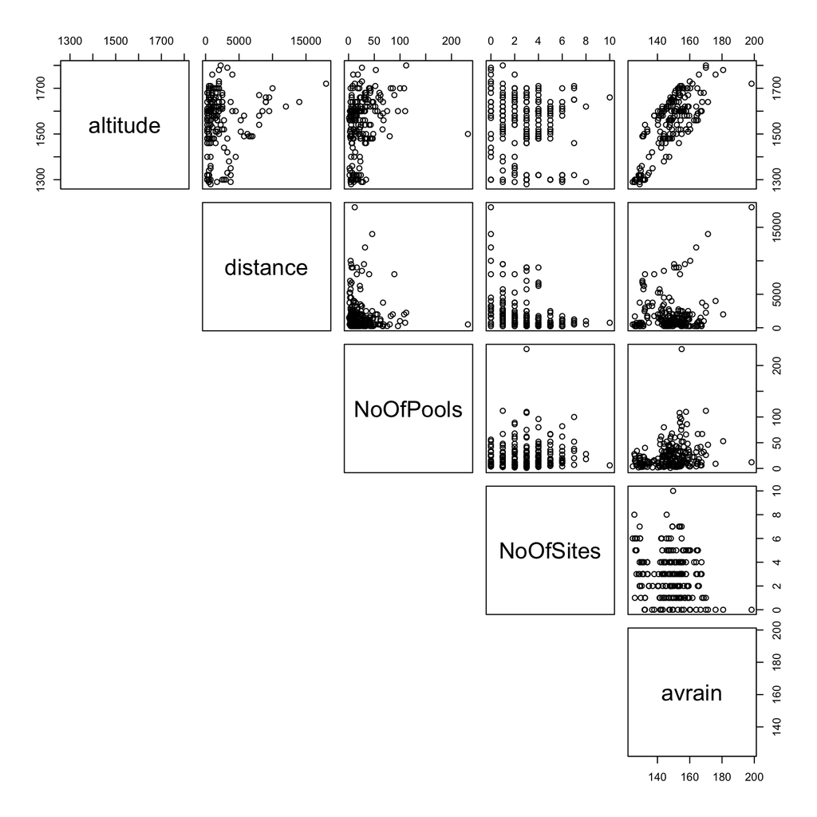

```r
#check for co-linearity among the four predictor variables
pairs(frogs[,5:9], lower.panel = NULL) #use all rows of columns 5 through 9
```

One very important thing you should do next is change the global options for how R functions handle missing data. By making this change, a function will not work if data are missing. This is required if you use the `dredge` function for exploratory data analysis.

```r
# change na. action
options(na.action = "na.fail")
```

```r
#First, fit 4 candidate linear models to explain variation in density
mod1<-lm(pres.abs~distance+altitude, data = frogs)
mod2<-lm(pres.abs~NoOfPools+altitude, data = frogs)
mod3<-lm(pres.abs~NoOfPools+distance, data = frogs)
mod4<-lm(pres.abs~NoOfPools+distance+altitude, data = frogs)
```

We can now use the `model.sel` function to conduct model selection. The default model selection criteria is Akaike’s information criteria (AIC) with small sample bias adjustment, AIC<sub>c</sub>. Here we’ll create an object `out.put` that contains all of the model selection information.

```r
# use the model.sel function to conduct model selection
# and put output into object out.put
out.put<-model.sel(mod1,mod2,mod3,mod4)
out.put
```

```
## Model selection table
##      (Intrc)      alttd      dstnc    NOfPl df   logLik  AICc delta weight
## mod4   1.864 -0.0009690 -4.780e-05 0.003975  5 -125.718 261.7  0.00  0.984
## mod1   1.592 -0.0007208 -5.390e-05           4 -131.143 270.5  8.75  0.012
## mod3   0.417            -5.762e-05 0.002666  4 -132.642 273.5 11.75  0.003
## mod2   2.096 -0.0011900            0.004699  4 -133.393 275.0 13.25  0.001
## Models ranked by AICc(x)
```

The models are sorted from best (top) to worst (bottom). Looks like `mod4`, containing an intercept (Int), distance (dstnc), altitude (alttd), and number of pools(NOfPl)) is best with a weight of 0.984. It is 0.984/0.012 = 82 times more likely to be the best explanation (hypothesis) for variation in density.

Here we can use the `subset` function to select the models that meet the criteria. Note that the weights are re-normalized for the models selected. That is, they are adjusted so that they add to one. not very helpful.

```r
# create a confidence set of models using the subset function
# select models with delta AICc less than 5
# IMPORTANT: Weights have been renormalized!!
subset(out.put, delta <5)
```

```
## Model selection table
##      (Intrc)     alttd     dstnc    NOfPl df   logLik  AICc delta weight
## mod4   1.864 -0.000969 -4.78e-05 0.003975  5 -125.718 261.7     0      1
## Models ranked by AICc(x)
```

```r
# select models using Royall's 1/8 rule for strength of evidence
#https://www.stat.fi/isi99/proceedings/arkisto/varasto/roya0578.pdf
# IMPORTANT: Weights have been renormalized!!
subset(out.put, 1/8 < weight/max(out.put$weight))
```

```
## Model selection table
##      (Intrc)     alttd     dstnc    NOfPl df   logLik  AICc delta weight
## mod4   1.864 -0.000969 -4.78e-05 0.003975  5 -125.718 261.7     0      1
## Models ranked by AICc(x)
```

Not much different than delta < 5 above. Let’s try another criteria based on the cumulative sum of the model weights.

```r
# select models 95% cumulative weight criteria
# IMPORTANT: Weights have been renormalized!!
subset(out.put, cumsum(out.put$weight) <= 1)
```

```
## Model selection table
##      (Intrc)      alttd      dstnc    NOfPl df   logLik  AICc delta weight
## mod4   1.864 -0.0009690 -4.780e-05 0.003975  5 -125.718 261.7  0.00  0.984
## mod1   1.592 -0.0007208 -5.390e-05           4 -131.143 270.5  8.75  0.012
## mod3   0.417            -5.762e-05 0.002666  4 -132.642 273.5 11.75  0.003
## mod2   2.096 -0.0011900            0.004699  4 -133.393 275.0 13.25  0.001
## Models ranked by AICc(x)
```

In most circumstances, you would like to include model selection results in a table in a report, publication, or thesis. Here, we need to coerce the output from the `model.sel` function into a dataframe. The first c elements of that data frame contain what we want. How do I know that? I first created the dataframe and used the “str” function to see what elements were in the dataframe.

```r
# coerce the object out.put into a data frame
# elements 6-10 in out.put have what we want
sel.table<-as.data.frame(out.put)[5:9]
sel.table
```

```
##      df    logLik     AICc     delta      weight
## mod4  5 -125.7182 261.7277  0.000000 0.983559011
## mod1  4 -131.1428 270.4788  8.751124 0.012374225
## mod3  4 -132.6423 273.4778 11.750187 0.002762357
## mod2  4 -133.3926 274.9785 13.250857 0.001304408
```

This is a bit messy and not ready for any report. Let’s clean this up a bit – first by rounding.

```r
# a little clean-up, lets round things a bit
sel.table[,2:3]<- round(sel.table[,2:3],2)
sel.table[,4:5]<- round(sel.table[,4:5],3)
sel.table
```

```
##      df  logLik   AICc  delta weight
## mod4  5 -125.72 261.73  0.000  0.984
## mod1  4 -131.14 270.48  8.751  0.012
## mod3  4 -132.64 273.48 11.750  0.003
## mod2  4 -133.39 274.98 13.251  0.001
```

```r
# that’s better
```

```r
# model selection table; sorted by BIC
model.sel(mod1,mod2,mod3,mod4, rank = BIC)
```

```
## Model selection table
##      (Intrc)      alttd      dstnc    NOfPl df   logLik   BIC delta weight
## mod4   1.864 -0.0009690 -4.780e-05 0.003975  5 -125.718 278.2  0.00  0.921
## mod1   1.592 -0.0007208 -5.390e-05           4 -131.143 283.7  5.49  0.059
## mod3   0.417            -5.762e-05 0.002666  4 -132.642 286.7  8.49  0.013
## mod2   2.096 -0.0011900            0.004699  4 -133.393 288.2  9.99  0.006
## Models ranked by BIC(x)
```

```r
#consistent AIC with Fishers information matrix
model.sel(mod1,mod2,mod3,mod4, rank = CAICF)
```

```
## Model selection table
##      (Intrc)      alttd      dstnc    NOfPl df   logLik CAICF delta weight
## mod2   2.096 -0.0011900            0.004699  4 -133.393 333.1  0.00  0.840
## mod3   0.417            -5.762e-05 0.002666  4 -132.642 337.8  4.65  0.082
## mod1   1.592 -0.0007208 -5.390e-05           4 -131.143 337.9  4.76  0.078
## mod4   1.864 -0.0009690 -4.780e-05 0.003975  5 -125.718 348.0 14.86  0.000
## Models ranked by CAICF(x)
```

There also are `MuMin` functions for calculating model selection criteria, such as AIC, AIC<sub>c</sub>, BIC and Mallows Cp, an ad hoc model selection criterion, not recommended. Here lets only compare two models using AIC.

```r
#AIC
AIC(mod1,mod2)
```

```
##      df      AIC
## mod1  4 270.2855
## mod2  4 274.7853
```

Note that above, the df is actually the number of model parameters, usually defined as K.

The **relative importance of individual parameters** can also be examined using the model weights. Here, the Akaike weights for each model that contains the parameter of interest are summed. These have been defined as importance weights and you can obtain them from a `model.sel` object using the “importance” function.

```r
# Importance weights for individual predictor variables
# calculated using the `sw` function

sw(out.put) #Per-variable sum of model weights
```

```
##                      distance altitude NoOfPools
## Sum of weights:      1.00     1.00     0.99
## N containing models:    3        3        3
```

```r
# Model average using all candidate models, always use revised.var = TRUE
MA.ests<-model.avg(out.put, revised.var = TRUE)
MA.ests
```

```
##
## Call:
## model.avg(object = out.put, revised.var = TRUE)
##
## Component models:
## '123' '12'  '23'  '13'
##
## Coefficients:
##        (Intercept)   NoOfPools      distance      altitude
## full      1.857277 0.003922878 -4.784497e-05 -0.0009635531
## subset    1.857277 0.003972029 -4.790746e-05 -0.0009662222
```

Another useful `MuMIn` function is `dredge`. However, you should only use is for exploratory purposes. Data dredging is strongly discouraged and can result in spurious (and irrelevant or worse, wrong) results and inference. So read the message below and users beware.

```r
## FOR EXPLORATORY PURPOSES ONLY!!! NEVER EVER DO THIS FOR A REAL
## STUDY
# fit model with all parameters
all.parms<-lm(pres.abs~NoOfPools+distance+altitude, data = frogs)

# the dredge function fits all combinations
# of the variables in the all.parms model fit above
results<-dredge(all.parms)
```

```
## Fixed term is "(Intercept)"
```

```r
results
```

```
## Global model call: lm(formula = pres.abs ~ NoOfPools + distance + altitude, data = frogs)
## ---
## Model selection table
##   (Intrc)      alttd      dstnc    NOfPl df   logLik  AICc delta weight
## 8  1.8640 -0.0009690 -4.780e-05 0.003975  5 -125.718 261.7  0.00  0.983
## 4  1.5920 -0.0007208 -5.390e-05           4 -131.143 270.5  8.75  0.012
## 7  0.4170            -5.762e-05 0.002666  4 -132.642 273.5 11.75  0.003
## 6  2.0960 -0.0011900            0.004699  4 -133.393 275.0 13.25  0.001
## 3  0.4891            -6.024e-05           3 -135.173 276.5 14.73  0.001
## 2  1.8020 -0.0009239                      3 -140.554 287.2 25.50  0.000
## 5  0.2922                       0.003204  3 -143.436 293.0 31.26  0.000
## 1  0.3726                                 2 -146.757 297.6 35.84  0.000
## Models ranked by AICc(x)
```

```r
# grab best supported models
subset(results, delta <5)
```

```
## Global model call: lm(formula = pres.abs ~ NoOfPools + distance + altitude, data = frogs)
## ---
## Model selection table
##   (Intrc)     alttd     dstnc    NOfPl df   logLik  AICc delta weight
## 8   1.864 -0.000969 -4.78e-05 0.003975  5 -125.718 261.7     0      1
## Models ranked by AICc(x)
```

```r
#grab best model
subset(results, delta == 0)
```

```
## Global model call: lm(formula = pres.abs ~ NoOfPools + distance + altitude, data = frogs)
## ---
## Model selection table
##   (Intrc)     alttd     dstnc    NOfPl df   logLik  AICc delta weight
## 8   1.864 -0.000969 -4.78e-05 0.003975  5 -125.718 261.7     0      1
## Models ranked by AICc(x)
```

```r
# calculate variable importance weights
sw(results)
```

```
##                      distance altitude NoOfPools
## Sum of weights:      1.00     1.00     0.99
## N containing models:    4        4        4
```

Notice above that every parameter is in the same number of models.

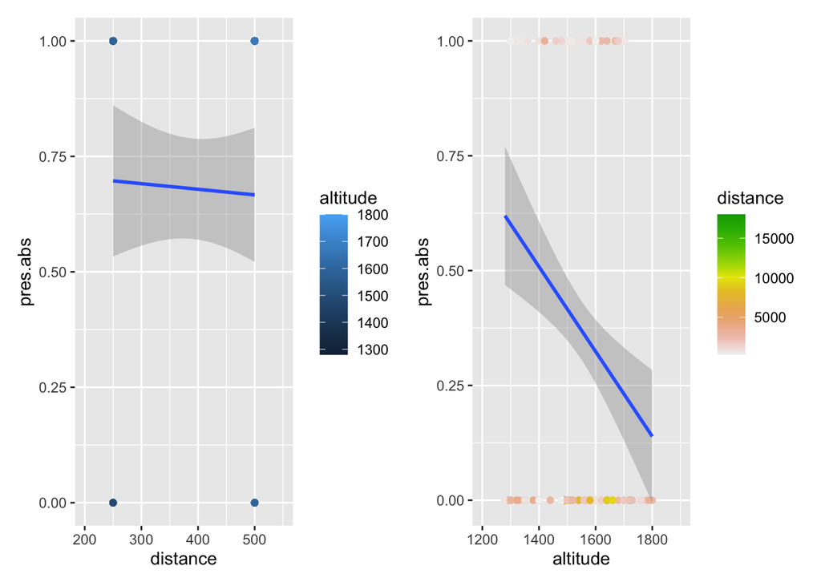

```r
p1 <- ggplot(frogs, aes(distance, pres.abs, colour = altitude)) +
  geom_point() +
  geom_smooth(method="lm")+
  scale_x_continuous(limits = c(200,550))

p2 <- ggplot(frogs, aes(altitude, pres.abs, colour = distance)) +
  geom_point() +
  geom_smooth(method="lm") +
  scale_colour_gradientn(colours = terrain.colors(10, rev=TRUE)) +
  scale_x_continuous(limits = c(1200,1900))

p1+p2
```